# KNN_REGRESION

```r
library(GGally)
library(dplyr)
library(tidyverse)
library(class)
library(ggplot2)
library(caret)
```

```r
porcentaje_na <- sapply(train_data, function(x) sum(is.na(x)) / length(x)) * 100

columnas_a_eliminar <- names(porcentaje_na[porcentaje_na > 75])
print(columnas_a_eliminar)
```

```
## [1] "Alley"       "PoolQC"      "Fence"       "MiscFeature"
```

```r
train_data <- train_data[, !names(train_data) %in% columnas_a_eliminar]
test_data <- test_data[, !names(test_data) %in% columnas_a_eliminar]
```

```r
numeric_columns <- train_data %>% select(where(is.numeric)) %>% names ()
categorical_columns <- train_data %>% select(where(~ !is.numeric(.))) %>% names()

preProc_num_train <- preProcess(train_data[, numeric_columns], method = "medianImpute")
preProc_num_test <- preProcess(test_data[, numeric_columns], method = "medianImpute")

train_data[, numeric_columns] <- predict(preProc_num_train, train_data[, numeric_columns])
test_data[, numeric_columns] <- predict(preProc_num_test, test_data[, numeric_columns])


niveles_por_columna <- sapply(test_data[, categorical_columns], function(x) length(unique(x)))
# Mostrar las columnas con un solo nivel (me dio un error antes con la funcion del encoder)
columnas_con_un_solo_nivel <- names(niveles_por_columna[niveles_por_columna == 1])
print("Columnas con un solo nivel:")
```

```
## [1] "Columnas con un solo nivel:"
```

```r
print(columnas_con_un_solo_nivel)
```

```
## [1] "Utilities"
```

```r
# Eliminar columnas con un solo nivel
train_data <- train_data[, !names(train_data) %in% columnas_con_un_solo_nivel]
test_data <- test_data[, !names(test_data) %in% columnas_con_un_solo_nivel]

# Actualizar
categorical_columns <- train_data %>% select(where(~ !is.numeric(.))) %>% names()
```

```r
# Crear un encoder para las variables categóricas
encoder <- dummyVars("~ .", data = train_data[, categorical_columns], fullRank = FALSE)

# Aplicar el encoder a los datos de entrenamiento y prueba
train_categorical_encoded <- as.data.frame(predict(encoder, newdata = train_data[, categorical_columns]))
test_categorical_encoded <- as.data.frame(predict(encoder, newdata = test_data[, categorical_columns]))

# Verificar si faltan columnas en test_categorical_encoded
columnas_faltantes <- setdiff(names(train_categorical_encoded), names(test_categorical_encoded))

# Agregar las columnas faltantes a test_categorical_encoded con valores 0
for (col in columnas_faltantes) {
  test_categorical_encoded[[col]] <- 0
}

# Reordenar las columnas de test_categorical_encoded para que coincidan con train_categorical_encoded
test_categorical_encoded <- test_categorical_encoded[, names(train_categorical_encoded)]

# data ya con encoded y datos jutnados
train_encoded <- cbind(train_data[, numeric_columns], train_categorical_encoded)
test_encoded <- cbind(test_data[, numeric_columns], test_categorical_encoded)


# Imputar valores faltantes en las columnas numéricas con la media
for (i in 1:ncol(train_encoded)) {
  if (is.numeric(train_encoded[, i])) {  # Solo aplicamos a columnas numéricas
    train_encoded[is.na(train_encoded[, i]), i] <- mean(train_encoded[, i], na.rm = TRUE)
  }
}

for (i in 1:ncol(test_encoded)) {
  if (is.numeric(test_encoded[, i])) {  # Solo aplicamos a columnas numéricas
    test_encoded[is.na(test_encoded[, i]), i] <- mean(test_encoded[, i], na.rm = TRUE)
  }
}

# Verificar valores faltantes en los datos de entrenamiento y prueba
#colSums(is.na(train_encoded))
#colSums(is.na(test_encoded))

# Verificar valores faltantes en los datos
print("Valores faltantes en train_encoded:")
```

```
## [1] "Valores faltantes en train_encoded:"
```

```r
print(colSums(is.na(train_encoded)))
```

[output not shown]

[output cut: 127 more lines]

[output not shown]

```r
print("Variables que estan en train")
```

```
## [1] "Variables que estan en train"
```

```r
print(ncol(train_encoded))
```

```
## [1] 271
```

```r
print("Valores faltantes en test_encoded:")
```

```
## [1] "Valores faltantes en test_encoded:"
```

```r
print(colSums(is.na(test_encoded)))
```

[output not shown]

[output cut: 127 more lines]

[output not shown]

```r
print("Variables que estan en test")
```

```
## [1] "Variables que estan en test"
```

```r
print(ncol(test_encoded))
```

```
## [1] 271
```

## 1.Elabore un modelo de regresión usando K nearest Neighbors (KNN), el conjunto de entrenamiento y la variable respuesta SalesPrice. Prediga con el modelo y explique los resultados a los que llega. Asegúrese que los conjuntos de entrenamiento y prueba sean los mismos de las entregas anteriores para que los modelos sean comparables.

```r
set.seed(123)


# Definir el valor de k a mano
k_vecinos <- round(sqrt(nrow(train_encoded)), 0)

parametros <- expand.grid(k = k_vecinos)

# entranmiento (en el ejemplo en canvas se hacía el training de una forma similar pero esta me parcio apropiada tambie, ya que se excluye completamente la variable respuesta del data set)
modelo_knn <- train(
  SalePrice~.,
  data = train_encoded,
  method = "knn",
  preProcess = c("center", "scale"),  # Normalización
  tuneGrid = parametros  # Valor de k
)

# Mostrar el modelo entrenado
print("Este es el modelo resultante con los datos del training")
```

```
## [1] "Este es el modelo resultante con los datos del training"
```

```r
print(modelo_knn)
```

```
## k-Nearest Neighbors
##
## 1021 samples
##  270 predictor
##
## Pre-processing: centered (270), scaled (270)
## Resampling: Bootstrapped (25 reps)
## Summary of sample sizes: 1021, 1021, 1021, 1021, 1021, 1021, ...
## Resampling results:
##
##   RMSE      Rsquared   MAE
##   47063.15  0.7098627  28763.05
##
## Tuning parameter 'k' was held constant at a value of 32
```

Con el print lo que vemos es el entrenamiento con el set de datos al que llamamos train_encoded. Este resultado ya muestra un MAE y un RMSE auqneu aún no hayamos hecho las predicciones. Pero por el método de aprendizaje KNN y la función que utilizamos de la librería CARET esta automáticamente hace una evaluación interna del modelo. Obteniendo como resultados:

- RMSE: 47063.15
- Rsquared: 0.7098627
- MAE: 28763.05

```r
print("Ahora aqui ya es donde se realiza la prediccion usando el set de datos de test")
```

```
## [1] "Ahora aqui ya es donde se realiza la prediccion usando el set de datos de test"
```

```r
predicciones <- predict(modelo_knn, newdata = test_encoded)
```

## 2.Analice los resultados del modelo de regresión usando KNN. ¿Qué tan bien le fue prediciendo? Utilice las métricas correctas.

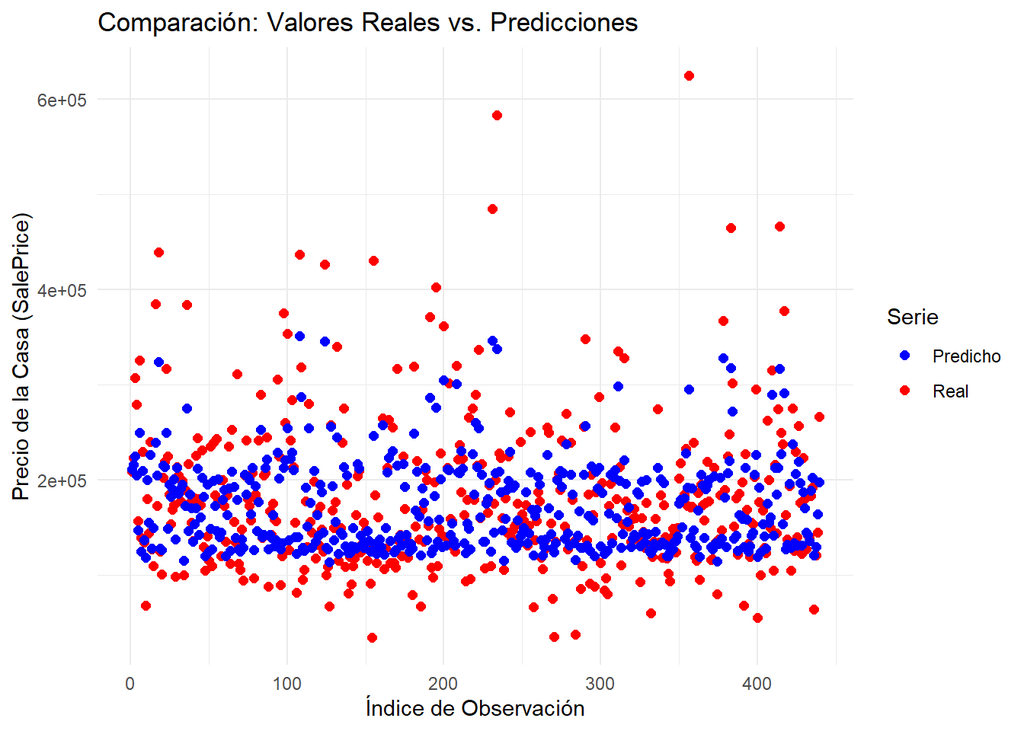

```r
# Crear el dataframe de resultados
df_resultados <- data.frame(
  Índice = 1:length(test_encoded$SalePrice),  # Índice de cada observación
  Real = test_encoded$SalePrice,              # Valores reales
  Predicho = predicciones                     # Valores predichos
)

# Graficar ambas series
ggplot(df_resultados) +
  geom_point(aes(x = Índice, y = Real, color = "Real"), size = 2) +  # Puntos rojos (valores reales)
  geom_point(aes(x = Índice, y = Predicho, color = "Predicho"), size = 2) +  # Puntos azules (predicciones)
  scale_color_manual(values = c("Real" = "red", "Predicho" = "blue")) +  # Definir colores
  labs(
    title = "Comparación: Valores Reales vs. Predicciones",
    x = "Índice de Observación",
    y = "Precio de la Casa (SalePrice)",
    color = "Serie"
  ) +
  theme_minimal()
```

```r
# Calcular métricas de evaluación
rmse <- sqrt(mean((df_resultados$Real - df_resultados$Predicho)^2))
print(paste("RMSE:", rmse))
```

```
## [1] "RMSE: 44760.8908122481"
```

```r
media_real <- mean(df_resultados$Real)

rmse_porcentual <- (rmse / media_real)

# Mostrar el RMSE porcentual
print(paste("RMSE porcentual:", rmse_porcentual))
```

```
## [1] "RMSE porcentual: 0.246838652763759"
```

```r
rsquared <- cor(df_resultados$Real, df_resultados$Predicho)^2
print(paste("R²:", rsquared))
```

```
## [1] "R²: 0.779855236064131"
```

Viendo estos resultados de predicciones sobre el conjunto de testing podemos notar distintas cosas interesantes. Lo primero es en la gráfica donde se ven las diferencias entre el valor real y su correpondiente predicción. Se puede ver que cuando el precio de la casa es muy alto o muy bajo, al modelo se le dificulta realmente acercarse al valor real, la desviación de la predicción mayor es en esas partes. Mientras que en el centro y un poco abajo del centro se ve que los valores predichos (azules), se encuentran más cerca de los valores reales.

Con respecto al RMSE los resultados son regulares, se tiene un R^2 de 77.98% y RMSE de 44760.89, osea casi $45K dolares de diferencia en el precio de una cas, lo cuál si representa una diferencia significativa en el contexto que se está analizando, el precio de una casa.Si lo vemos como un porcentaje para entender la seriedad del errror colocamos también la desviación del predicción como un porcentaje. La predicción se desvía un 24.68% aproximadamente, casi 1/4 del precio, por lo que el modelo no es tan bueno. Es importante mencionar que para este primer modelod eregresión se tomaron todas las varaibles del data set al igual que en otros modelos hechos anteriormente.

```r
# Cargar las librerías necesarias
library(caret)
library(ggplot2)

# Definir la grilla de valores para k (de 1 a 25)
parametros <- expand.grid(k = seq(1, 25, by = 1))


set.seed(123)
modelo_knn_reg <- train(
  SalePrice ~ .,                  # Fórmula: SalePrice en función de todas las demás variables
  data = train_encoded,           # Conjunto de entrenamiento
  method = "knn",
  preProcess = c("center", "scale"),  # Normalización de los datos
  tuneGrid = parametros,
  trControl = trainControl(method = "cv", number = 10),
  metric = "RMSE"
)

print("Este es el modelo resultante con los datos del training")
```

```
## [1] "Este es el modelo resultante con los datos del training"
```

```r
print(modelo_knn_reg)
```

```
## k-Nearest Neighbors
##
## 1021 samples
##  270 predictor
##
## Pre-processing: centered (270), scaled (270)
## Resampling: Cross-Validated (10 fold)
## Summary of sample sizes: 918, 919, 919, 920, 919, 918, ...
## Resampling results across tuning parameters:
##
##   k   RMSE      Rsquared   MAE
##    1  55766.17  0.5587342  33745.37
##    2  49313.28  0.6461107  29744.28
##    3  45398.06  0.6927441  28227.76
##    4  44145.69  0.7074671  27719.85
##    5  43956.54  0.7154166  27377.70
##    6  43504.79  0.7222044  27100.49
##    7  43359.36  0.7259939  27068.99
##    8  43213.53  0.7303202  26813.46
##    9  43106.85  0.7337342  26801.68
##   10  43311.59  0.7317378  26990.63
##   11  43500.97  0.7314353  27056.60
##   12  43397.53  0.7356836  27069.23
##   13  43374.48  0.7399559  27098.64
##   14  43906.92  0.7344152  27368.51
##   15  43954.46  0.7362868  27469.74
##   16  44018.75  0.7378485  27422.55
##   17  43878.30  0.7415282  27418.98
##   18  43964.90  0.7414921  27598.01
##   19  44191.28  0.7400637  27638.90
##   20  44303.06  0.7403698  27785.84
##   21  44450.41  0.7403971  27897.00
##   22  44596.01  0.7395330  28041.60
##   23  44733.09  0.7399312  28151.88
##   24  44856.30  0.7389743  28253.23
##   25  45025.67  0.7375406  28354.95
##
## RMSE was used to select the optimal model using the smallest value.
## The final value used for the model was k = 9.
```

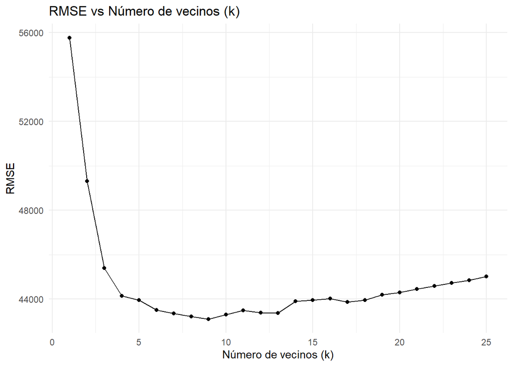

```r
# Graficar el RMSE en función de k
ggplot(modelo_knn_reg) +
  theme_minimal() +
  labs(title = "RMSE vs Número de vecinos (k)",
       x = "Número de vecinos (k)",
       y = "RMSE")
```

```r
# Seleccionar el mejor valor de k
mejor_k <- modelo_knn_reg$bestTune$k
cat("El mejor valor de k es:", mejor_k, "\n")
```

```
## El mejor valor de k es: 9
```

```r
predicciones <- predict(modelo_knn_reg, newdata = test_encoded)

rmse_test <- sqrt(mean((predicciones - test_encoded$SalePrice)^2))
cat("RMSE en el conjunto de prueba:", rmse_test, "\n")
```

```
## RMSE en el conjunto de prueba: 40787.62
```